# Module 201

#### Hemi-module gene counts:

181 probesets in hemi-module A.  
54 probesets in hemi-module B.  
Note: While the mapping of probesets to genes is usually one-to-one, some genes are targeted by multiple probesets, some probesets target multiple genes, and some probesets do not target any genes (i.e., the region of the genome they match is no longer considered genic).

#### Contrast SVE:

Signed variance explained (SVE) provides an indication of how similar a set of fold changes are to a gene module’s weight vector. An SVE value of 0.3, for example, indicates that 30% of the variance explained by the entire module set is accounted for by the module in question. Shown here are the SVE values for this module across a compendium of fold changes (contrasts). Extreme SVE values (e.g., > 0.05) indicate that those contrasts specifically induce (orange dots) or specifically repress (blue dots) this module. Examining the experimental conditions being compared in such contrasts (see tables below the figure) may provide insight into the gene module’s function.

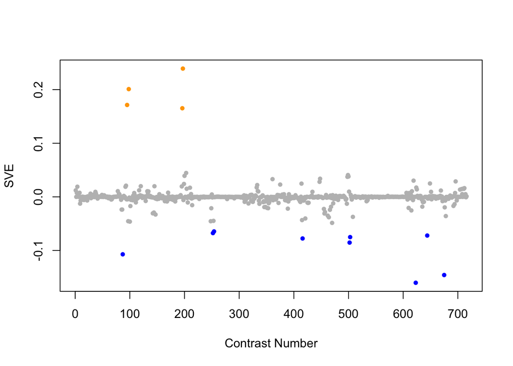

Positive SVE Contrasts:

|  | Contrast.Num | SVE | GEO.GSE | Cond.1 | Cond.2 | Mutation |
| --- | --- | --- | --- | --- | --- | --- |
| GSE43959.s1t1.vs.s2t1 | 197 | 0.24 | GSE43959 | N2 young adult on E. coli OP50 rep 1 | N2 young adult on E. coli HT115 rep 1 |  |
| GSE5793.s2t2.vs.s1t2 | 98 | 0.20 | GSE5793 | Celegans_OP50_8hours_RepA | Celegans_gacA_8hours_RepA |  |
| GSE5793.s2t1.vs.s1t1 | 95 | 0.17 | GSE5793 | Celegans_OP50_4hours_RepA | Celegans_gacA_4hours_RepA |  |
| GSE43959.s1t1.vs.s3t1 | 196 | 0.17 | GSE43959 | N2 young adult on E. coli OP50 rep 1 | N2 young adult on Comamonas DA1877 rep 1 |  |
| GSE43952.s1t1.vs.s0t1 | 203 | 0.04 | GSE43952 | metr-1(ok521) fed Comamonas DA1877 rep 1 | N2 gravid adult fed Comamonas DA1877 rep 1 | metr-1 |

Negative SVE Contrasts:

|  | Contrast.Num | SVE | GEO.GSE | Cond.1 | Cond.2 | Mutation |
| --- | --- | --- | --- | --- | --- | --- |
| GSE20053.s1t1.vs.s0t1 | 623 | -0.16 | GSE20053 | C. elegans N2_Y. pestis KIM5_24h_Sample A | C. elegans N2_E. coli OP50_24h_Sample A |  |
| GSE13258.s4t1.vs.s0t1 | 675 | -0.15 | GSE13258 | alg-1 mutant, biological rep 1 | wild-type, biological rep 1 | alg-1 |
| GSE6547.s1t3.vs.s0t3 | 87 | -0.11 | GSE6547 | lin-35(n745) worms at L4 stage, first replicate | N2 (wt) worms at L4 stage, first replicate | lin-35 |
| GSE22660.s1t1.vs.s0t1 | 502 | -0.09 | GSE22660 | 100ng/ml ivermectin exposure, biological rep 1 | 100ng/ml DMSO control, biological rep 1 |  |
| GSE29951.s0t2.vs.s0t1 | 416 | -0.08 | GSE29951 | C.elegans wild type raised in the presence of Cd, rep1 | C.elegans wild type raised in the absence of Cd, rep1 |  |
| GSE22660.s1t2.vs.s0t2 | 503 | -0.08 | GSE22660 | 1ug/ml ivermectin exposure, biological rep 1 | 1ug/ml DMSO control, biological rep 1 |  |
| GSE16915.s1t1.vs.s3t1 | 644 | -0.07 | GSE16915 | control sample | bio-electrosprayed sample |  |
| GSE42192.s1t2.vs.s1t1 | 252 | -0.07 | GSE42192 | C.elegans fed with CNCM I-3690 10 days rep1 | C.elegans fed with CNCM I-3690 3 days rep1 |  |
| GSE42192.s0t2.vs.s0t1 | 254 | -0.06 | GSE42192 | C.elegans fed with E.coli OP50 10 days rep1 | C.elegans fed with E.coli OP50 3 days rep1 |  |

$~$

#### Contrast SVE, Up-Regulated Genes Only:

Calculating SVE for up-regulated and down-regulated genes separately may be more informative in many cases than projecting the up- and down- gene sets together. This is due to the fact that the weight distribution of many modules is highly skewed, indicating that only one of the hemi-modules may be biologically meaningful (i.e., a set of genes are strongly correlated by only a few genes (or none) are strongly anti-correlated to that set.)

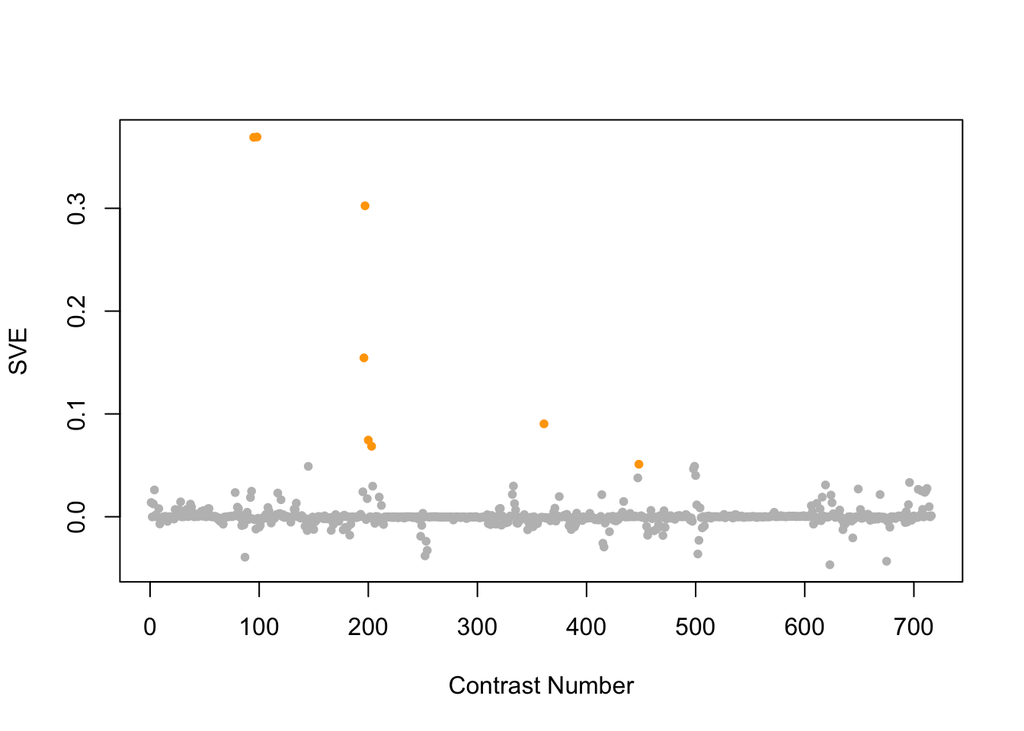

Positive SVE Contrasts:

|  | Contrast.Num | SVE | GEO.GSE | Cond.1 | Cond.2 | Mutation |
| --- | --- | --- | --- | --- | --- | --- |
| GSE5793.s2t2.vs.s1t2 | 98 | 0.37 | GSE5793 | Celegans_OP50_8hours_RepA | Celegans_gacA_8hours_RepA |  |
| GSE5793.s2t1.vs.s1t1 | 95 | 0.37 | GSE5793 | Celegans_OP50_4hours_RepA | Celegans_gacA_4hours_RepA |  |
| GSE43959.s1t1.vs.s2t1 | 197 | 0.30 | GSE43959 | N2 young adult on E. coli OP50 rep 1 | N2 young adult on E. coli HT115 rep 1 |  |
| GSE43959.s1t1.vs.s3t1 | 196 | 0.15 | GSE43959 | N2 young adult on E. coli OP50 rep 1 | N2 young adult on Comamonas DA1877 rep 1 |  |
| GSE37432.s2t1.vs.s0t1 | 361 | 0.09 | GSE37432 | piwi n4503 nDf57 rep1 | N2 rep1 | prg-1;prg-2 |
| GSE43959.s1t2.vs.s3t2 | 200 | 0.07 | GSE43959 | N2 gravid adult on E. coli OP50 rep 1 | N2 gravid adult on Comamonas DA1877 rep 1 |  |
| GSE43952.s1t1.vs.s0t1 | 203 | 0.07 | GSE43952 | metr-1(ok521) fed Comamonas DA1877 rep 1 | N2 gravid adult fed Comamonas DA1877 rep 1 | metr-1 |
| GSE27401.s1t1.vs.s2t1 | 448 | 0.05 | GSE27401 | Heat Killed E coli #1 | Heat Killed C. albicans #1 |  |

Negative SVE Contrasts:

|  | Contrast.Num | SVE | GEO.GSE | Cond.1 | Cond.2 | Mutation |
| --- | --- | --- | --- | --- | --- | --- |
| GSE20053.s1t1.vs.s0t1 | 623 | -0.05 | GSE20053 | C. elegans N2_Y. pestis KIM5_24h_Sample A | C. elegans N2_E. coli OP50_24h_Sample A |  |
| GSE13258.s4t1.vs.s0t1 | 675 | -0.04 | GSE13258 | alg-1 mutant, biological rep 1 | wild-type, biological rep 1 | alg-1 |
| GSE6547.s1t3.vs.s0t3 | 87 | -0.04 | GSE6547 | lin-35(n745) worms at L4 stage, first replicate | N2 (wt) worms at L4 stage, first replicate | lin-35 |
| GSE42192.s1t2.vs.s1t1 | 252 | -0.04 | GSE42192 | C.elegans fed with CNCM I-3690 10 days rep1 | C.elegans fed with CNCM I-3690 3 days rep1 |  |
| GSE22660.s1t1.vs.s0t1 | 502 | -0.04 | GSE22660 | 100ng/ml ivermectin exposure, biological rep 1 | 100ng/ml DMSO control, biological rep 1 |  |

$~$

#### Contrast SVE, Down-Regulated Genes Only:

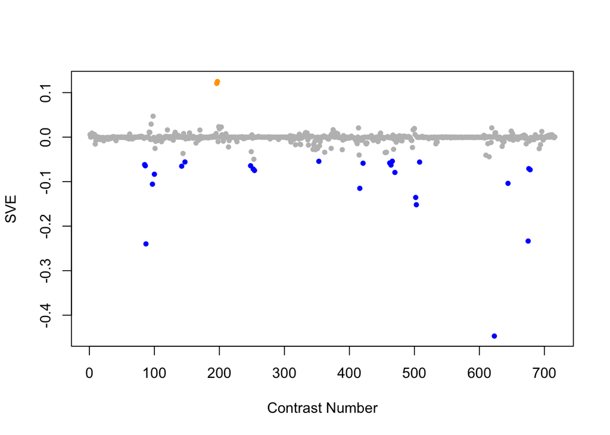

Positive SVE Contrasts:

|  | Contrast.Num | SVE | GEO.GSE | Cond.1 | Cond.2 | Mutation |
| --- | --- | --- | --- | --- | --- | --- |
| GSE43959.s1t1.vs.s2t1 | 197 | 0.12 | GSE43959 | N2 young adult on E. coli OP50 rep 1 | N2 young adult on E. coli HT115 rep 1 |  |
| GSE43959.s1t1.vs.s3t1 | 196 | 0.12 | GSE43959 | N2 young adult on E. coli OP50 rep 1 | N2 young adult on Comamonas DA1877 rep 1 |  |
| GSE5793.s2t2.vs.s1t2 | 98 | 0.05 | GSE5793 | Celegans_OP50_8hours_RepA | Celegans_gacA_8hours_RepA |  |
| GSE5793.s2t1.vs.s1t1 | 95 | 0.03 | GSE5793 | Celegans_OP50_4hours_RepA | Celegans_gacA_4hours_RepA |  |
| GSE43959.s1t2.vs.s4t2 | 199 | 0.02 | GSE43959 | N2 gravid adult on E. coli OP50 rep 1 | N2 gravid adult on 1:1000 Comamonas DA1877 rep 1 |  |

Negative SVE Contrasts:

|  | Contrast.Num | SVE | GEO.GSE | Cond.1 | Cond.2 | Mutation |
| --- | --- | --- | --- | --- | --- | --- |
| GSE20053.s1t1.vs.s0t1 | 623 | -0.45 | GSE20053 | C. elegans N2_Y. pestis KIM5_24h_Sample A | C. elegans N2_E. coli OP50_24h_Sample A |  |
| GSE6547.s1t3.vs.s0t3 | 87 | -0.24 | GSE6547 | lin-35(n745) worms at L4 stage, first replicate | N2 (wt) worms at L4 stage, first replicate | lin-35 |
| GSE13258.s4t1.vs.s0t1 | 675 | -0.23 | GSE13258 | alg-1 mutant, biological rep 1 | wild-type, biological rep 1 | alg-1 |
| GSE22660.s1t2.vs.s0t2 | 503 | -0.15 | GSE22660 | 1ug/ml ivermectin exposure, biological rep 1 | 1ug/ml DMSO control, biological rep 1 |  |
| GSE22660.s1t1.vs.s0t1 | 502 | -0.14 | GSE22660 | 100ng/ml ivermectin exposure, biological rep 1 | 100ng/ml DMSO control, biological rep 1 |  |
| GSE29951.s0t2.vs.s0t1 | 416 | -0.12 | GSE29951 | C.elegans wild type raised in the presence of Cd, rep1 | C.elegans wild type raised in the absence of Cd, rep1 |  |
| GSE5793.s3t1.vs.s2t1 | 97 | -0.11 | GSE5793 | Celegans_PA14_4hours_RepA | Celegans_OP50_4hours_RepA |  |
| GSE16915.s1t1.vs.s3t1 | 644 | -0.10 | GSE16915 | control sample | bio-electrosprayed sample |  |
| GSE5793.s3t2.vs.s2t2 | 100 | -0.08 | GSE5793 | Celegans_PA14_8hours_RepA | Celegans_OP50_8hours_RepA |  |
| GSE23528A.s2t6.vs.s0t6 | 470 | -0.08 | GSE23528 | Adult at T22 in WC, time-series experiment 1 | Adult at T22, non-entrained control time-series experiment 4 |  |
| GSE42192.s0t2.vs.s0t1 | 254 | -0.07 | GSE42192 | C.elegans fed with E.coli OP50 10 days rep1 | C.elegans fed with E.coli OP50 3 days rep1 |  |
| GSE13258.s1t1.vs.s0t1 | 678 | -0.07 | GSE13258 | zfp-1 mutant, biological rep 1 | wild-type, biological rep 1 | zfp-1 |
| GSE42192.s1t2.vs.s1t1 | 252 | -0.07 | GSE42192 | C.elegans fed with CNCM I-3690 10 days rep1 | C.elegans fed with CNCM I-3690 3 days rep1 |  |
| GSE13258.s3t1.vs.s0t1 | 676 | -0.07 | GSE13258 | lin-35 mutant, biological rep 1 | wild-type, biological rep 1 | lin-35 |
| GSE50513.s2t1.vs.s1t1 | 142 | -0.07 | GSE50513 | L4440 PA14 - rep 1 | L4440 OP50 - rep 1 |  |
| GSE6547.s1t1.vs.s0t1 | 86 | -0.06 | GSE6547 | lin-35(n745) worms at embryonic stage, first replicate | N2 (wt) worms at embryonic stage, first replicate | lin-35 |
| GSE42192.s1t2.vs.s0t2 | 248 | -0.06 | GSE42192 | C.elegans fed with CNCM I-3690 10 days rep1 | C.elegans fed with E.coli OP50 10 days rep1 |  |
| GSE23528A.s2t4.vs.s0t4 | 464 | -0.06 | GSE23528 | Adult at T14 in WC, time-series experiment 1 | Adult at T14, non-entrained control time-series experiment 4 |  |
| GSE6547.s1t2.vs.s0t2 | 85 | -0.06 | GSE6547 | lin-35(n745) worms at L1 stage, first replicate | N2 (wt) worms at L1 stage, first replicate | lin-35 |
| GSE28494.s1t2.vs.s0t2 | 421 | -0.06 | GSE28494 | lin-54(n3423) dissected germline 1 | wild-type N2 dissected germline 1 | lin-54 |
| GSE23528A.s2t3.vs.s0t3 | 462 | -0.06 | GSE23528 | Adult at T10 in WC, time-series experiment 1 | Adult at T10, non-entrained control time-series experiment 4 |  |
| GSE21819.s1t1.vs.s0t1 | 508 | -0.06 | GSE21819 | CELEGANS_RN6390_8H_REP1 | CELEGANS_OP50_8H_REP1 |  |
| GSE50513.s4t1.vs.s3t1 | 147 | -0.06 | GSE50513 | zip-2 PA14 - rep 1 | zip-2 OP50 - rep 1 |  |
| GSE38997.s4t3.vs.s4t1 | 353 | -0.05 | GSE38997 | experiment 1 UVC-exposed samples at 48 h 1u48 | experiment 4 UVC-exposed samples at 3 h 4u3 |  |
| GSE23528A.s2t5.vs.s0t5 | 466 | -0.05 | GSE23528 | Adult at T18 in WC, time-series experiment 1 | Adult at T18, non-entrained control time-series experiment 4 |  |

$~$

$~$

#### GO Term Enrichment:

This analysis tests each hemi-module for enrichment of specific GO terms. Only gene-level annotations (e.g., as would be found on the gene’s page in Wormbase) are tested - the hierarchical structure of the GO ontology is not taken into account.

*Note: At least the top two most enriched terms from each GO domain (BP/MF/CC) are shown, even when not statistically significant.*

##### Enriched GO terms: Hemi-module A

| ID | GO.Term | GO Domain | Raw p-value | Adj p-value |
| --- | --- | --- | --- | --- |
| [GO_0055114](http://amigo.geneontology.org/amigo/term/GO:0055114) | oxidation-reduction process | BP | 1.94e-10 | 7.06e-07 |
| [GO_0006730](http://amigo.geneontology.org/amigo/term/GO:0006730) | one-carbon metabolic process | BP | 5.18e-09 | 9.43e-06 |
| [GO_0006635](http://amigo.geneontology.org/amigo/term/GO:0006635) | fatty acid beta-oxidation | BP | 3.45e-06 | 3.59e-03 |
| [GO_0009253](http://amigo.geneontology.org/amigo/term/GO:0009253) | peptidoglycan catabolic process | BP | 3.94e-06 | 3.59e-03 |
| [GO_0016998](http://amigo.geneontology.org/amigo/term/GO:0016998) | cell wall macromolecule catabolic process | BP | 9.78e-06 | 7.12e-03 |
| [GO_0009086](http://amigo.geneontology.org/amigo/term/GO:0009086) | methionine biosynthetic process | BP | 5.36e-05 | 3.25e-02 |
| [GO_0006850](http://amigo.geneontology.org/amigo/term/GO:0006850) | mitochondrial pyruvate transmembrane transport | BP | 1.00e-04 | 4.06e-02 |
| [GO_0035461](http://amigo.geneontology.org/amigo/term/GO:0035461) | vitamin transmembrane transport | BP | 1.00e-04 | 4.06e-02 |
| [GO_0051180](http://amigo.geneontology.org/amigo/term/GO:0051180) | vitamin transport | BP | 1.00e-04 | 4.06e-02 |
| [GO_0006556](http://amigo.geneontology.org/amigo/term/GO:0006556) | S-adenosylmethionine biosynthetic process | BP | 2.99e-04 | 8.38e-02 |
| [GO_0006574](http://amigo.geneontology.org/amigo/term/GO:0006574) | valine catabolic process | BP | 2.99e-04 | 8.38e-02 |
| [GO_0009236](http://amigo.geneontology.org/amigo/term/GO:0009236) | cobalamin biosynthetic process | BP | 2.99e-04 | 8.38e-02 |
| [GO_0019432](http://amigo.geneontology.org/amigo/term/GO:0019432) | triglyceride biosynthetic process | BP | 2.99e-04 | 8.38e-02 |
| [GO_0016491](http://amigo.geneontology.org/amigo/term/GO:0016491) | oxidoreductase activity | MF | 7.78e-10 | 1.59e-06 |
| [GO_0003985](http://amigo.geneontology.org/amigo/term/GO:0003985) | acetyl-CoA C-acetyltransferase activity | MF | 9.92e-07 | 8.71e-04 |
| [GO_0003824](http://amigo.geneontology.org/amigo/term/GO:0003824) | catalytic activity | MF | 1.28e-06 | 8.71e-04 |
| [GO_0050660](http://amigo.geneontology.org/amigo/term/GO:0050660) | flavin adenine dinucleotide binding | MF | 1.93e-06 | 9.87e-04 |
| [GO_0003988](http://amigo.geneontology.org/amigo/term/GO:0003988) | acetyl-CoA C-acyltransferase activity | MF | 3.94e-06 | 1.61e-03 |
| [GO_0005542](http://amigo.geneontology.org/amigo/term/GO:0005542) | folic acid binding | MF | 1.00e-04 | 2.56e-02 |
| [GO_0050833](http://amigo.geneontology.org/amigo/term/GO:0050833) | pyruvate transmembrane transporter activity | MF | 1.00e-04 | 2.56e-02 |
| [GO_0090482](http://amigo.geneontology.org/amigo/term/GO:0090482) | vitamin transmembrane transporter activity | MF | 1.00e-04 | 2.56e-02 |
| [GO_0003796](http://amigo.geneontology.org/amigo/term/GO:0003796) | lysozyme activity | MF | 1.13e-04 | 2.57e-02 |
| [GO_0016627](http://amigo.geneontology.org/amigo/term/GO:0016627) | oxidoreductase activity, acting on the CH-CH group of donors | MF | 2.48e-04 | 5.07e-02 |
| [GO_0004478](http://amigo.geneontology.org/amigo/term/GO:0004478) | methionine adenosyltransferase activity | MF | 2.99e-04 | 5.55e-02 |
| [GO_0047617](http://amigo.geneontology.org/amigo/term/GO:0047617) | acyl-CoA hydrolase activity | MF | 3.33e-04 | 5.67e-02 |
| [GO_0005739](http://amigo.geneontology.org/amigo/term/GO:0005739) | mitochondrion | CC | 1.87e-09 | 1.74e-06 |
| [GO_0005634](http://amigo.geneontology.org/amigo/term/GO:0005634) | nucleus | CC | 6.41e-04 | 2.97e-01 |

##### Enriched GO terms: Hemi-module B

| ID | GO.Term | GO Domain | Raw p-value | Adj p-value |
| --- | --- | --- | --- | --- |
| [GO_0045087](http://amigo.geneontology.org/amigo/term/GO:0045087) | innate immune response | BP | 1.10e-06 | 4.02e-03 |
| [GO_0008152](http://amigo.geneontology.org/amigo/term/GO:0008152) | metabolic process | BP | 7.31e-04 | 1.00e+00 |
| [GO_0016788](http://amigo.geneontology.org/amigo/term/GO:0016788) | hydrolase activity, acting on ester bonds | MF | 4.15e-05 | 8.48e-02 |
| [GO_0016798](http://amigo.geneontology.org/amigo/term/GO:0016798) | hydrolase activity, acting on glycosyl bonds | MF | 2.47e-04 | 2.52e-01 |
| [GO_0005764](http://amigo.geneontology.org/amigo/term/GO:0005764) | lysosome | CC | 1.25e-04 | 1.16e-01 |
| [GO_0005634](http://amigo.geneontology.org/amigo/term/GO:0005634) | nucleus | CC | 2.13e-03 | 8.70e-01 |

$~$

$~$

#### Tissue Enrichment:

This analysis tests each hemi-module for enrichment of genes associated with anatomy terms. Negative enrichment scores indicate fewer hemi-module genes than expected by random chance were associated with the anatomy term in question.

##### Enriched tissues: Hemi-module A

No significant annotations.

##### Enriched tissues: Hemi-module B

No significant annotations.

$~$

$~$

#### HOMER promoter motif enrichment:

This analysis tests each hemi-module for enrichment of 108 known *C. elegans* transcription factor binding site motifs (see [108 CE motifs](https://katiepod.github.io//all.worm.motifs.html)) using the HOMER (Hypergeometric Optimization of Motif EnRichment) software (see [PMID:20513432](https://pubmed.ncbi.nlm.nih.gov/20513432)). HOMER was run using default parameters on sequences 1 kb upstream of the transcription start site.

##### Motif enrichment: Hemi-module A

Total target sequences = 146  
Total background sequences = 41105  
* - possible false positive

Rank

Motif

P-value

log P-pvalue

% of Targets

% of Background

STD(Bg STD)

Best Match/Details

Motif File

1

[figure not shown]

1e-16

-3.806e+01

38.36%

11.28%

267.4bp (312.2bp)

elt-6/MA1439.1/Jaspar(0.646)  
[More Information](https://katiepod.github.io/HomerResults/m201_a_hemi_genes.txt.out.1kb/homerResults/motif1.info.html) | [Similar Motifs Found](https://katiepod.github.io/HomerResults/m201_a_hemi_genes.txt.out.1kb/homerResults/motif1.similar.html)

[motif file (matrix)](https://katiepod.github.io/HomerResults/m201_a_hemi_genes.txt.out.1kb/homerResults/motif1.motif)

2

[figure not shown]

1e-12

-2.839e+01

18.49%

3.29%

257.2bp (330.2bp)

POL012.1_TATA-Box/Jaspar(0.821)  
[More Information](https://katiepod.github.io/HomerResults/m201_a_hemi_genes.txt.out.1kb/homerResults/motif2.info.html) | [Similar Motifs Found](https://katiepod.github.io/HomerResults/m201_a_hemi_genes.txt.out.1kb/homerResults/motif2.similar.html)

[motif file (matrix)](https://katiepod.github.io/HomerResults/m201_a_hemi_genes.txt.out.1kb/homerResults/motif2.motif)

3 *

[figure not shown]

1e-11

-2.759e+01

39.04%

14.86%

287.9bp (318.9bp)

ELT-3(Gata)/cElegans-L1-ELT3-ChIP-Seq(modEncode)/Homer(0.940)  
[More Information](https://katiepod.github.io/HomerResults/m201_a_hemi_genes.txt.out.1kb/homerResults/motif3.info.html) | [Similar Motifs Found](https://katiepod.github.io/HomerResults/m201_a_hemi_genes.txt.out.1kb/homerResults/motif3.similar.html)

[motif file (matrix)](https://katiepod.github.io/HomerResults/m201_a_hemi_genes.txt.out.1kb/homerResults/motif3.motif)

4 *

[figure not shown]

1e-11

-2.536e+01

16.44%

2.91%

312.9bp (298.5bp)

fkh-9/MA1440.1/Jaspar(0.537)  
[More Information](https://katiepod.github.io/HomerResults/m201_a_hemi_genes.txt.out.1kb/homerResults/motif4.info.html) | [Similar Motifs Found](https://katiepod.github.io/HomerResults/m201_a_hemi_genes.txt.out.1kb/homerResults/motif4.similar.html)

[motif file (matrix)](https://katiepod.github.io/HomerResults/m201_a_hemi_genes.txt.out.1kb/homerResults/motif4.motif)

5 *

[figure not shown]

1e-10

-2.521e+01

6.16%

0.17%

305.0bp (302.5bp)

ceh-48/MA0921.1/Jaspar(0.615)  
[More Information](https://katiepod.github.io/HomerResults/m201_a_hemi_genes.txt.out.1kb/homerResults/motif5.info.html) | [Similar Motifs Found](https://katiepod.github.io/HomerResults/m201_a_hemi_genes.txt.out.1kb/homerResults/motif5.similar.html)

[motif file (matrix)](https://katiepod.github.io/HomerResults/m201_a_hemi_genes.txt.out.1kb/homerResults/motif5.motif)

6 *

[figure not shown]

1e-10

-2.504e+01

5.48%

0.11%

261.8bp (325.7bp)

pha-4/MA0546.1/Jaspar(0.644)  
[More Information](https://katiepod.github.io/HomerResults/m201_a_hemi_genes.txt.out.1kb/homerResults/motif6.info.html) | [Similar Motifs Found](https://katiepod.github.io/HomerResults/m201_a_hemi_genes.txt.out.1kb/homerResults/motif6.similar.html)

[motif file (matrix)](https://katiepod.github.io/HomerResults/m201_a_hemi_genes.txt.out.1kb/homerResults/motif6.motif)

7 *

[figure not shown]

1e-10

-2.380e+01

4.79%

0.07%

299.6bp (260.9bp)

MF0005.1_Forkhead_class/Jaspar(0.623)  
[More Information](https://katiepod.github.io/HomerResults/m201_a_hemi_genes.txt.out.1kb/homerResults/motif7.info.html) | [Similar Motifs Found](https://katiepod.github.io/HomerResults/m201_a_hemi_genes.txt.out.1kb/homerResults/motif7.similar.html)

[motif file (matrix)](https://katiepod.github.io/HomerResults/m201_a_hemi_genes.txt.out.1kb/homerResults/motif7.motif)

8 *

[figure not shown]

1e-9

-2.247e+01

4.79%

0.09%

365.7bp (234.1bp)

unc-30/MA1443.1/Jaspar(0.677)  
[More Information](https://katiepod.github.io/HomerResults/m201_a_hemi_genes.txt.out.1kb/homerResults/motif8.info.html) | [Similar Motifs Found](https://katiepod.github.io/HomerResults/m201_a_hemi_genes.txt.out.1kb/homerResults/motif8.similar.html)

[motif file (matrix)](https://katiepod.github.io/HomerResults/m201_a_hemi_genes.txt.out.1kb/homerResults/motif8.motif)

9 *

[figure not shown]

1e-9

-2.219e+01

8.22%

0.62%

312.6bp (304.5bp)

lin-14/MA0261.1/Jaspar(0.612)  
[More Information](https://katiepod.github.io/HomerResults/m201_a_hemi_genes.txt.out.1kb/homerResults/motif9.info.html) | [Similar Motifs Found](https://katiepod.github.io/HomerResults/m201_a_hemi_genes.txt.out.1kb/homerResults/motif9.similar.html)

[motif file (matrix)](https://katiepod.github.io/HomerResults/m201_a_hemi_genes.txt.out.1kb/homerResults/motif9.motif)

10 *

[figure not shown]

1e-9

-2.210e+01

8.22%

0.62%

225.6bp (316.0bp)

PL0014.1_mxl-1::mdl-1/Jaspar(0.529)  
[More Information](https://katiepod.github.io/HomerResults/m201_a_hemi_genes.txt.out.1kb/homerResults/motif10.info.html) | [Similar Motifs Found](https://katiepod.github.io/HomerResults/m201_a_hemi_genes.txt.out.1kb/homerResults/motif10.similar.html)

[motif file (matrix)](https://katiepod.github.io/HomerResults/m201_a_hemi_genes.txt.out.1kb/homerResults/motif10.motif)

11 *

[figure not shown]

1e-9

-2.187e+01

7.53%

0.49%

279.3bp (309.7bp)

nhr-6/MA1451.1/Jaspar(0.645)  
[More Information](https://katiepod.github.io/HomerResults/m201_a_hemi_genes.txt.out.1kb/homerResults/motif11.info.html) | [Similar Motifs Found](https://katiepod.github.io/HomerResults/m201_a_hemi_genes.txt.out.1kb/homerResults/motif11.similar.html)

[motif file (matrix)](https://katiepod.github.io/HomerResults/m201_a_hemi_genes.txt.out.1kb/homerResults/motif11.motif)

12 *

[figure not shown]

1e-9

-2.178e+01

6.16%

0.26%

354.7bp (281.6bp)

MF0010.1_Homeobox_class/Jaspar(0.616)  
[More Information](https://katiepod.github.io/HomerResults/m201_a_hemi_genes.txt.out.1kb/homerResults/motif12.info.html) | [Similar Motifs Found](https://katiepod.github.io/HomerResults/m201_a_hemi_genes.txt.out.1kb/homerResults/motif12.similar.html)

[motif file (matrix)](https://katiepod.github.io/HomerResults/m201_a_hemi_genes.txt.out.1kb/homerResults/motif12.motif)

13 *

[figure not shown]

1e-9

-2.152e+01

13.70%

2.38%

266.4bp (299.7bp)

POL012.1_TATA-Box/Jaspar(0.546)  
[More Information](https://katiepod.github.io/HomerResults/m201_a_hemi_genes.txt.out.1kb/homerResults/motif13.info.html) | [Similar Motifs Found](https://katiepod.github.io/HomerResults/m201_a_hemi_genes.txt.out.1kb/homerResults/motif13.similar.html)

[motif file (matrix)](https://katiepod.github.io/HomerResults/m201_a_hemi_genes.txt.out.1kb/homerResults/motif13.motif)

14 *

[figure not shown]

1e-9

-2.151e+01

4.79%

0.10%

186.6bp (314.6bp)

lin-54/MA1450.1/Jaspar(0.510)  
[More Information](https://katiepod.github.io/HomerResults/m201_a_hemi_genes.txt.out.1kb/homerResults/motif14.info.html) | [Similar Motifs Found](https://katiepod.github.io/HomerResults/m201_a_hemi_genes.txt.out.1kb/homerResults/motif14.similar.html)

[motif file (matrix)](https://katiepod.github.io/HomerResults/m201_a_hemi_genes.txt.out.1kb/homerResults/motif14.motif)

15 *

[figure not shown]

1e-9

-2.079e+01

10.27%

1.27%

274.6bp (302.0bp)

nhr-6/MA1451.1/Jaspar(0.639)  
[More Information](https://katiepod.github.io/HomerResults/m201_a_hemi_genes.txt.out.1kb/homerResults/motif15.info.html) | [Similar Motifs Found](https://katiepod.github.io/HomerResults/m201_a_hemi_genes.txt.out.1kb/homerResults/motif15.similar.html)

[motif file (matrix)](https://katiepod.github.io/HomerResults/m201_a_hemi_genes.txt.out.1kb/homerResults/motif15.motif)

16 *

[figure not shown]

1e-9

-2.077e+01

11.64%

1.72%

258.1bp (307.5bp)

elt-6/MA1439.1/Jaspar(0.627)  
[More Information](https://katiepod.github.io/HomerResults/m201_a_hemi_genes.txt.out.1kb/homerResults/motif16.info.html) | [Similar Motifs Found](https://katiepod.github.io/HomerResults/m201_a_hemi_genes.txt.out.1kb/homerResults/motif16.similar.html)

[motif file (matrix)](https://katiepod.github.io/HomerResults/m201_a_hemi_genes.txt.out.1kb/homerResults/motif16.motif)

17 *

[figure not shown]

1e-8

-2.051e+01

10.96%

1.52%

253.1bp (305.9bp)

PHA-4(Forkhead)/cElegans-Embryos-PHA4-ChIP-Seq(modEncode)/Homer(0.532)  
[More Information](https://katiepod.github.io/HomerResults/m201_a_hemi_genes.txt.out.1kb/homerResults/motif17.info.html) | [Similar Motifs Found](https://katiepod.github.io/HomerResults/m201_a_hemi_genes.txt.out.1kb/homerResults/motif17.similar.html)

[motif file (matrix)](https://katiepod.github.io/HomerResults/m201_a_hemi_genes.txt.out.1kb/homerResults/motif17.motif)

18 *

[figure not shown]

1e-8

-1.900e+01

8.90%

1.02%

236.2bp (300.0bp)

pha-4/MA0546.1/Jaspar(0.551)  
[More Information](https://katiepod.github.io/HomerResults/m201_a_hemi_genes.txt.out.1kb/homerResults/motif18.info.html) | [Similar Motifs Found](https://katiepod.github.io/HomerResults/m201_a_hemi_genes.txt.out.1kb/homerResults/motif18.similar.html)

[motif file (matrix)](https://katiepod.github.io/HomerResults/m201_a_hemi_genes.txt.out.1kb/homerResults/motif18.motif)

19 *

[figure not shown]

1e-8

-1.884e+01

5.48%

0.25%

159.5bp (267.0bp)

nhr-6/MA1451.1/Jaspar(0.511)  
[More Information](https://katiepod.github.io/HomerResults/m201_a_hemi_genes.txt.out.1kb/homerResults/motif19.info.html) | [Similar Motifs Found](https://katiepod.github.io/HomerResults/m201_a_hemi_genes.txt.out.1kb/homerResults/motif19.similar.html)

[motif file (matrix)](https://katiepod.github.io/HomerResults/m201_a_hemi_genes.txt.out.1kb/homerResults/motif19.motif)

20 *

[figure not shown]

1e-8

-1.849e+01

11.64%

2.01%

270.4bp (298.7bp)

PHA-4(Forkhead)/cElegans-Embryos-PHA4-ChIP-Seq(modEncode)/Homer(0.524)  
[More Information](https://katiepod.github.io/HomerResults/m201_a_hemi_genes.txt.out.1kb/homerResults/motif20.info.html) | [Similar Motifs Found](https://katiepod.github.io/HomerResults/m201_a_hemi_genes.txt.out.1kb/homerResults/motif20.similar.html)

[motif file (matrix)](https://katiepod.github.io/HomerResults/m201_a_hemi_genes.txt.out.1kb/homerResults/motif20.motif)

21 *

[figure not shown]

1e-7

-1.814e+01

23.97%

8.41%

265.7bp (307.6bp)

nhr-6/MA1451.1/Jaspar(0.619)  
[More Information](https://katiepod.github.io/HomerResults/m201_a_hemi_genes.txt.out.1kb/homerResults/motif21.info.html) | [Similar Motifs Found](https://katiepod.github.io/HomerResults/m201_a_hemi_genes.txt.out.1kb/homerResults/motif21.similar.html)

[motif file (matrix)](https://katiepod.github.io/HomerResults/m201_a_hemi_genes.txt.out.1kb/homerResults/motif21.motif)

22 *

[figure not shown]

1e-7

-1.742e+01

17.81%

5.08%

265.5bp (306.2bp)

POL003.1_GC-box/Jaspar(0.600)  
[More Information](https://katiepod.github.io/HomerResults/m201_a_hemi_genes.txt.out.1kb/homerResults/motif22.info.html) | [Similar Motifs Found](https://katiepod.github.io/HomerResults/m201_a_hemi_genes.txt.out.1kb/homerResults/motif22.similar.html)

[motif file (matrix)](https://katiepod.github.io/HomerResults/m201_a_hemi_genes.txt.out.1kb/homerResults/motif22.motif)

23 *

[figure not shown]

1e-7

-1.707e+01

6.85%

0.62%

310.7bp (293.8bp)

efl-1/MA0541.1/Jaspar(0.635)  
[More Information](https://katiepod.github.io/HomerResults/m201_a_hemi_genes.txt.out.1kb/homerResults/motif23.info.html) | [Similar Motifs Found](https://katiepod.github.io/HomerResults/m201_a_hemi_genes.txt.out.1kb/homerResults/motif23.similar.html)

[motif file (matrix)](https://katiepod.github.io/HomerResults/m201_a_hemi_genes.txt.out.1kb/homerResults/motif23.motif)

24 *

[figure not shown]

1e-7

-1.627e+01

20.55%

6.96%

281.4bp (304.4bp)

PL0007.1_mxl-3/Jaspar(0.930)  
[More Information](https://katiepod.github.io/HomerResults/m201_a_hemi_genes.txt.out.1kb/homerResults/motif24.info.html) | [Similar Motifs Found](https://katiepod.github.io/HomerResults/m201_a_hemi_genes.txt.out.1kb/homerResults/motif24.similar.html)

[motif file (matrix)](https://katiepod.github.io/HomerResults/m201_a_hemi_genes.txt.out.1kb/homerResults/motif24.motif)

25 *

[figure not shown]

1e-7

-1.616e+01

4.79%

0.24%

258.5bp (264.8bp)

MF0006.1_bZIP_cEBP-like_subclass/Jaspar(0.648)  
[More Information](https://katiepod.github.io/HomerResults/m201_a_hemi_genes.txt.out.1kb/homerResults/motif25.info.html) | [Similar Motifs Found](https://katiepod.github.io/HomerResults/m201_a_hemi_genes.txt.out.1kb/homerResults/motif25.similar.html)

[motif file (matrix)](https://katiepod.github.io/HomerResults/m201_a_hemi_genes.txt.out.1kb/homerResults/motif25.motif)

26 *

[figure not shown]

1e-6

-1.554e+01

10.96%

2.19%

200.9bp (306.0bp)

eor-1/MA0543.1/Jaspar(0.778)  
[More Information](https://katiepod.github.io/HomerResults/m201_a_hemi_genes.txt.out.1kb/homerResults/motif26.info.html) | [Similar Motifs Found](https://katiepod.github.io/HomerResults/m201_a_hemi_genes.txt.out.1kb/homerResults/motif26.similar.html)

[motif file (matrix)](https://katiepod.github.io/HomerResults/m201_a_hemi_genes.txt.out.1kb/homerResults/motif26.motif)

27 *

[figure not shown]

1e-6

-1.382e+01

16.44%

5.34%

269.7bp (317.0bp)

fkh-9/MA1440.1/Jaspar(0.639)  
[More Information](https://katiepod.github.io/HomerResults/m201_a_hemi_genes.txt.out.1kb/homerResults/motif27.info.html) | [Similar Motifs Found](https://katiepod.github.io/HomerResults/m201_a_hemi_genes.txt.out.1kb/homerResults/motif27.similar.html)

[motif file (matrix)](https://katiepod.github.io/HomerResults/m201_a_hemi_genes.txt.out.1kb/homerResults/motif27.motif)

28 *

[figure not shown]

1e-5

-1.341e+01

2.05%

0.01%

369.7bp (267.8bp)

MF0010.1_Homeobox_class/Jaspar(0.646)  
[More Information](https://katiepod.github.io/HomerResults/m201_a_hemi_genes.txt.out.1kb/homerResults/motif28.info.html) | [Similar Motifs Found](https://katiepod.github.io/HomerResults/m201_a_hemi_genes.txt.out.1kb/homerResults/motif28.similar.html)

[motif file (matrix)](https://katiepod.github.io/HomerResults/m201_a_hemi_genes.txt.out.1kb/homerResults/motif28.motif)

29 *

[figure not shown]

1e-5

-1.320e+01

6.85%

0.95%

347.3bp (309.4bp)

POL010.1_DCE_S_III/Jaspar(0.584)  
[More Information](https://katiepod.github.io/HomerResults/m201_a_hemi_genes.txt.out.1kb/homerResults/motif29.info.html) | [Similar Motifs Found](https://katiepod.github.io/HomerResults/m201_a_hemi_genes.txt.out.1kb/homerResults/motif29.similar.html)

[motif file (matrix)](https://katiepod.github.io/HomerResults/m201_a_hemi_genes.txt.out.1kb/homerResults/motif29.motif)

30 *

[figure not shown]

1e-5

-1.249e+01

10.27%

2.45%

289.8bp (301.6bp)

cebp-1/MA1444.1/Jaspar(0.565)  
[More Information](https://katiepod.github.io/HomerResults/m201_a_hemi_genes.txt.out.1kb/homerResults/motif30.info.html) | [Similar Motifs Found](https://katiepod.github.io/HomerResults/m201_a_hemi_genes.txt.out.1kb/homerResults/motif30.similar.html)

[motif file (matrix)](https://katiepod.github.io/HomerResults/m201_a_hemi_genes.txt.out.1kb/homerResults/motif30.motif)

31 *

[figure not shown]

1e-2

-5.944e+00

2.05%

0.18%

171.9bp (335.6bp)

dpy-27/MA0540.1/Jaspar(0.502)  
[More Information](https://katiepod.github.io/HomerResults/m201_a_hemi_genes.txt.out.1kb/homerResults/motif31.info.html) | [Similar Motifs Found](https://katiepod.github.io/HomerResults/m201_a_hemi_genes.txt.out.1kb/homerResults/motif31.similar.html)

[motif file (matrix)](https://katiepod.github.io/HomerResults/m201_a_hemi_genes.txt.out.1kb/homerResults/motif31.motif)

##### Motif enrichment: Hemi-module B

Total target sequences = 43  
Total background sequences = 37790  
* - possible false positive

Rank

Motif

P-value

log P-pvalue

% of Targets

% of Background

STD(Bg STD)

Best Match/Details

Motif File

1

[figure not shown]

1e-12

-2.806e+01

34.88%

2.90%

331.0bp (320.4bp)

daf-16/MA1446.1/Jaspar(0.500)  
[More Information](https://katiepod.github.io/HomerResults/m201_b_hemi_genes.txt.out.1kb/homerResults/motif1.info.html) | [Similar Motifs Found](https://katiepod.github.io/HomerResults/m201_b_hemi_genes.txt.out.1kb/homerResults/motif1.similar.html)

[motif file (matrix)](https://katiepod.github.io/HomerResults/m201_b_hemi_genes.txt.out.1kb/homerResults/motif1.motif)

2 *

[figure not shown]

1e-11

-2.608e+01

13.95%

0.09%

352.8bp (360.3bp)

MF0009.1_TRP(MYB)_class/Jaspar(0.610)  
[More Information](https://katiepod.github.io/HomerResults/m201_b_hemi_genes.txt.out.1kb/homerResults/motif2.info.html) | [Similar Motifs Found](https://katiepod.github.io/HomerResults/m201_b_hemi_genes.txt.out.1kb/homerResults/motif2.similar.html)

[motif file (matrix)](https://katiepod.github.io/HomerResults/m201_b_hemi_genes.txt.out.1kb/homerResults/motif2.motif)

3 *

[figure not shown]

1e-10

-2.383e+01

30.23%

2.59%

242.0bp (324.1bp)

elt-2/MA1701.1/Jaspar(0.752)  
[More Information](https://katiepod.github.io/HomerResults/m201_b_hemi_genes.txt.out.1kb/homerResults/motif3.info.html) | [Similar Motifs Found](https://katiepod.github.io/HomerResults/m201_b_hemi_genes.txt.out.1kb/homerResults/motif3.similar.html)

[motif file (matrix)](https://katiepod.github.io/HomerResults/m201_b_hemi_genes.txt.out.1kb/homerResults/motif3.motif)

4 *

[figure not shown]

1e-10

-2.368e+01

13.95%

0.14%

232.8bp (288.3bp)

unc-30/MA1443.1/Jaspar(0.573)  
[More Information](https://katiepod.github.io/HomerResults/m201_b_hemi_genes.txt.out.1kb/homerResults/motif4.info.html) | [Similar Motifs Found](https://katiepod.github.io/HomerResults/m201_b_hemi_genes.txt.out.1kb/homerResults/motif4.similar.html)

[motif file (matrix)](https://katiepod.github.io/HomerResults/m201_b_hemi_genes.txt.out.1kb/homerResults/motif4.motif)

5 *

[figure not shown]

1e-9

-2.302e+01

9.30%

0.01%

242.1bp (343.8bp)

fkh-9/MA1440.1/Jaspar(0.562)  
[More Information](https://katiepod.github.io/HomerResults/m201_b_hemi_genes.txt.out.1kb/homerResults/motif5.info.html) | [Similar Motifs Found](https://katiepod.github.io/HomerResults/m201_b_hemi_genes.txt.out.1kb/homerResults/motif5.similar.html)

[motif file (matrix)](https://katiepod.github.io/HomerResults/m201_b_hemi_genes.txt.out.1kb/homerResults/motif5.motif)

6 *

[figure not shown]

1e-7

-1.832e+01

34.88%

5.87%

243.9bp (322.1bp)

POL009.1_DCE_S_II/Jaspar(0.534)  
[More Information](https://katiepod.github.io/HomerResults/m201_b_hemi_genes.txt.out.1kb/homerResults/motif6.info.html) | [Similar Motifs Found](https://katiepod.github.io/HomerResults/m201_b_hemi_genes.txt.out.1kb/homerResults/motif6.similar.html)

[motif file (matrix)](https://katiepod.github.io/HomerResults/m201_b_hemi_genes.txt.out.1kb/homerResults/motif6.motif)

7 *

[figure not shown]

1e-7

-1.807e+01

30.23%

4.19%

324.1bp (319.9bp)

nhr-6/MA1451.1/Jaspar(0.653)  
[More Information](https://katiepod.github.io/HomerResults/m201_b_hemi_genes.txt.out.1kb/homerResults/motif7.info.html) | [Similar Motifs Found](https://katiepod.github.io/HomerResults/m201_b_hemi_genes.txt.out.1kb/homerResults/motif7.similar.html)

[motif file (matrix)](https://katiepod.github.io/HomerResults/m201_b_hemi_genes.txt.out.1kb/homerResults/motif7.motif)

8 *

[figure not shown]

1e-7

-1.667e+01

11.63%

0.22%

232.0bp (361.2bp)

ces-2/MA0922.1/Jaspar(0.651)  
[More Information](https://katiepod.github.io/HomerResults/m201_b_hemi_genes.txt.out.1kb/homerResults/motif8.info.html) | [Similar Motifs Found](https://katiepod.github.io/HomerResults/m201_b_hemi_genes.txt.out.1kb/homerResults/motif8.similar.html)

[motif file (matrix)](https://katiepod.github.io/HomerResults/m201_b_hemi_genes.txt.out.1kb/homerResults/motif8.motif)

9 *

[figure not shown]

1e-6

-1.573e+01

18.60%

1.40%

325.4bp (306.9bp)

ceh-28/MA1445.1/Jaspar(0.545)  
[More Information](https://katiepod.github.io/HomerResults/m201_b_hemi_genes.txt.out.1kb/homerResults/motif9.info.html) | [Similar Motifs Found](https://katiepod.github.io/HomerResults/m201_b_hemi_genes.txt.out.1kb/homerResults/motif9.similar.html)

[motif file (matrix)](https://katiepod.github.io/HomerResults/m201_b_hemi_genes.txt.out.1kb/homerResults/motif9.motif)

10 *

[figure not shown]

1e-6

-1.548e+01

39.53%

9.62%

305.2bp (306.4bp)

POL008.1_DCE_S_I/Jaspar(0.686)  
[More Information](https://katiepod.github.io/HomerResults/m201_b_hemi_genes.txt.out.1kb/homerResults/motif10.info.html) | [Similar Motifs Found](https://katiepod.github.io/HomerResults/m201_b_hemi_genes.txt.out.1kb/homerResults/motif10.similar.html)

[motif file (matrix)](https://katiepod.github.io/HomerResults/m201_b_hemi_genes.txt.out.1kb/homerResults/motif10.motif)

11 *

[figure not shown]

1e-6

-1.481e+01

20.93%

2.21%

344.0bp (328.2bp)

fos-1/MA1448.1/Jaspar(0.610)  
[More Information](https://katiepod.github.io/HomerResults/m201_b_hemi_genes.txt.out.1kb/homerResults/motif11.info.html) | [Similar Motifs Found](https://katiepod.github.io/HomerResults/m201_b_hemi_genes.txt.out.1kb/homerResults/motif11.similar.html)

[motif file (matrix)](https://katiepod.github.io/HomerResults/m201_b_hemi_genes.txt.out.1kb/homerResults/motif11.motif)

12 *

[figure not shown]

1e-6

-1.459e+01

37.21%

8.99%

298.2bp (322.1bp)

elt-3/MA0542.1/Jaspar(0.818)  
[More Information](https://katiepod.github.io/HomerResults/m201_b_hemi_genes.txt.out.1kb/homerResults/motif12.info.html) | [Similar Motifs Found](https://katiepod.github.io/HomerResults/m201_b_hemi_genes.txt.out.1kb/homerResults/motif12.similar.html)

[motif file (matrix)](https://katiepod.github.io/HomerResults/m201_b_hemi_genes.txt.out.1kb/homerResults/motif12.motif)

13 *

[figure not shown]

1e-6

-1.417e+01

16.28%

1.17%

120.4bp (295.7bp)

ceh-38/MA1699.1/Jaspar(0.727)  
[More Information](https://katiepod.github.io/HomerResults/m201_b_hemi_genes.txt.out.1kb/homerResults/motif13.info.html) | [Similar Motifs Found](https://katiepod.github.io/HomerResults/m201_b_hemi_genes.txt.out.1kb/homerResults/motif13.similar.html)

[motif file (matrix)](https://katiepod.github.io/HomerResults/m201_b_hemi_genes.txt.out.1kb/homerResults/motif13.motif)

14 *

[figure not shown]

1e-5

-1.310e+01

9.30%

0.20%

161.3bp (284.2bp)

PL0015.1_hlh-2::hlh-14/Jaspar(0.657)  
[More Information](https://katiepod.github.io/HomerResults/m201_b_hemi_genes.txt.out.1kb/homerResults/motif14.info.html) | [Similar Motifs Found](https://katiepod.github.io/HomerResults/m201_b_hemi_genes.txt.out.1kb/homerResults/motif14.similar.html)

[motif file (matrix)](https://katiepod.github.io/HomerResults/m201_b_hemi_genes.txt.out.1kb/homerResults/motif14.motif)

15 *

[figure not shown]

1e-5

-1.245e+01

6.98%

0.06%

187.9bp (320.3bp)

nhr-6/MA1451.1/Jaspar(0.528)  
[More Information](https://katiepod.github.io/HomerResults/m201_b_hemi_genes.txt.out.1kb/homerResults/motif15.info.html) | [Similar Motifs Found](https://katiepod.github.io/HomerResults/m201_b_hemi_genes.txt.out.1kb/homerResults/motif15.similar.html)

[motif file (matrix)](https://katiepod.github.io/HomerResults/m201_b_hemi_genes.txt.out.1kb/homerResults/motif15.motif)

16 *

[figure not shown]

1e-4

-1.019e+01

27.91%

7.22%

326.5bp (312.1bp)

MF0011.1_HMG_class/Jaspar(0.744)  
[More Information](https://katiepod.github.io/HomerResults/m201_b_hemi_genes.txt.out.1kb/homerResults/motif16.info.html) | [Similar Motifs Found](https://katiepod.github.io/HomerResults/m201_b_hemi_genes.txt.out.1kb/homerResults/motif16.similar.html)

[motif file (matrix)](https://katiepod.github.io/HomerResults/m201_b_hemi_genes.txt.out.1kb/homerResults/motif16.motif)

17 *

[figure not shown]

1e-3

-8.283e+00

16.28%

2.96%

176.9bp (290.9bp)

SD0002.1_at_AC_acceptor/Jaspar(0.652)  
[More Information](https://katiepod.github.io/HomerResults/m201_b_hemi_genes.txt.out.1kb/homerResults/motif17.info.html) | [Similar Motifs Found](https://katiepod.github.io/HomerResults/m201_b_hemi_genes.txt.out.1kb/homerResults/motif17.similar.html)

[motif file (matrix)](https://katiepod.github.io/HomerResults/m201_b_hemi_genes.txt.out.1kb/homerResults/motif17.motif)

$~$

$~$

#### Promoter Word Enrichment:

This analysis tests each hemi-module for enrichment of specific promoter words. The list of promoter words tested was generated by running the MobyDick algorithm (see [PMID:10944202](https://pubmed.ncbi.nlm.nih.gov/10944202)) on the full set of *C. elegans* 2 Kbp promoters.

##### Enriched promoter words: Hemi-module A

| Word | RC | Raw.p.value | Adj.p.value |
| --- | --- | --- | --- |
| GTATAAAAG | CTTTTATAC | 2.12e-07 | 1.11e-03 |
| TCTTATC | GATAAGA | 5.46e-06 | 1.43e-02 |
| TTATCA | TGATAA | 8.45e-06 | 1.47e-02 |
| TCTTATCA | TGATAAGA | 4.93e-05 | 6.44e-02 |

##### Enriched promoter words: Hemi-module B

No significant words.

$~$

$~$

#### Promoter Word Depletion:

This analysis tests each hemi-module for depletion (under-enrichment) of specific promoter words. The list of promoter words tested was generated by running the MobyDick algorithm (see [PMID:10944202](https://pubmed.ncbi.nlm.nih.gov/10944202)) on the full set of *C. elegans* 2 Kbp promoters.

##### Depleted promoter words: Hemi-module A

No significant words.

##### Depleted promoter words: Hemi-module B

No significant words.

$~$

$~$

#### 3’-UTR Word Enrichment:

This analysis tests each hemi-module for enrichment of specific 3’-UTR words. The list of words tested was generated by running the MobyDick algorithm (see [PMID:10944202](https://pubmed.ncbi.nlm.nih.gov/10944202)) on the full set of *C. elegans* 3’-UTR sequences.

##### 3’-UTR words: Hemi-module A

No significant words.

##### 3’-UTR words: Hemi-module B

No significant words.

$~$

$~$

#### Hemi-module A genes

| affy_c_elegans | ensembl_gene_id | external_gene_name | module_weight | chromosome_name | strand | start_position | end_position |
| --- | --- | --- | --- | --- | --- | --- | --- |
| 184012_at | WBGene00005444 | srh-237 | 18.41 | V | 1 | 17090362 | 17091693 |
| 189402_s_at | WBGene00004062 | pmp-5 | 15.91 | V | -1 | 6662191 | 6665813 |
| 177235_s_at | WBGene00008436 | DH11.2 | 15.33 | II | 1 | 8012816 | 8015264 |
| 184116_s_at | WBGene00011487 | T05E12.6 | 14.29 | V | -1 | 17085002 | 17090023 |
| 177144_at | WBGene00003704 | nhr-114 | 13.77 | V | 1 | 4187185 | 4190008 |
| 193016_s_at | WBGene00012608 | hphd-1 | 13.69 | II | -1 | 12994358 | 12996571 |
| 184159_at | WBGene00011487 | T05E12.6 | 13.48 | V | -1 | 17085002 | 17090023 |
| 173996_at | WBGene00002096 | ins-13 | 12.53 | II | -1 | 5544585 | 5544851 |
| 173996_at | WBGene00015894 | acdh-2 | 12.53 | II | -1 | 5544781 | 5547490 |
| 177786_at | WBGene00009677 | F44A6.5 | 12.52 | X | -1 | 10217310 | 10218760 |
| 190145_s_at | WBGene00009334 | F32D8.12 | 12.49 | V | -1 | 10888572 | 10891030 |
| 190145_s_at | WBGene00043302 | F32D8.11 | 12.49 | V | -1 | 10887873 | 10889004 |
| 190705_s_at | WBGene00015894 | acdh-2 | 12.04 | II | -1 | 5544781 | 5547490 |
| 188822_at | WBGene00016943 | acdh-1 | 11.73 | I | 1 | 6497436 | 6499560 |
| 178688_s_at | WBGene00010657 | K08D8.3 | 11.72 | IV | -1 | 12903785 | 12906659 |
| 192782_at | WBGene00003658 | nhr-68 | 11.68 | V | 1 | 11573440 | 11575709 |
| 192200_at | WBGene00006510 | mtrr-1 | 11.67 | II | 1 | 9285932 | 9289136 |
| 190412_s_at | WBGene00001155 | ech-6 | 11.57 | III | -1 | 9751440 | 9752922 |
| 183902_at | WBGene00018393 | msra-1 | 11.56 | II | -1 | 7363216 | 7364107 |
| 185902_at | WBGene00017658 | F21C10.9 | 11.43 | V | -1 | 9097121 | 9098696 |
| 183330_s_at | WBGene00015623 | C09B8.4 | 11.22 | X | -1 | 6018442 | 6019936 |
| 182849_at | WBGene00012538 | Y37A1B.5 | 11.18 | IV | 1 | 14051200 | 14056676 |
| 192650_at | WBGene00000988 | dhs-25 | 10.92 | X | 1 | 1486473 | 1489326 |
| 190404_s_at | WBGene00018138 | folt-2 | 10.85 | V | -1 | 2872465 | 2875600 |
| 192692_s_at | WBGene00010055 | F54D5.12 | 9.67 | II | -1 | 11538904 | 11540630 |
| 192751_at | WBGene00020528 | lgc-54 | 9.39 | V | -1 | 6840217 | 6846590 |
| 181797_at | WBGene00008925 | F17H10.1 | 9.26 | X | 1 | 13105184 | 13108543 |
| 190067_at | WBGene00017301 | hach-1 | 9.26 | III | 1 | 5555404 | 5557318 |
| 172581_s_at | WBGene00043302 | F32D8.11 | 8.95 | V | -1 | 10887873 | 10889004 |
| 191860_at | WBGene00014092 | ZK822.5 | 8.92 | IV | 1 | 11937384 | 11940604 |

[output cut: 175 more lines]

#### Hemi-module B genes

| affy_c_elegans | ensembl_gene_id | external_gene_name | module_weight | chromosome_name | strand | start_position | end_position |
| --- | --- | --- | --- | --- | --- | --- | --- |
| 183624_at | WBGene00010125 | dod-22 | -8.45 | IV | 1 | 12965387 | 12967318 |
| 180909_at | WBGene00007867 | C32H11.4 | -8.32 | IV | 1 | 12921264 | 12923288 |
| 181534_s_at | WBGene00017199 | clec-45 | -7.64 | V | 1 | 7638105 | 7638622 |
| 181534_s_at | WBGene00017202 | clec-46 | -7.64 | V | -1 | 7637277 | 7637792 |
| 191294_at | WBGene00013866 | cbs-1 | -7.29 | X | 1 | 10054281 | 10057524 |
| 181322_at | WBGene00017199 | clec-45 | -6.49 | V | 1 | 7638105 | 7638622 |
| 177218_at | WBGene00021805 | Y53G8AM.5 | -6.21 | III | -1 | 3256730 | 3258395 |
| 192194_s_at | WBGene00000213 | asm-3 | -6.18 | IV | -1 | 520214 | 523809 |
| 188078_at | WBGene00009773 | lipl-2 | -6.04 | V | 1 | 9791567 | 9793234 |
| 181827_at | WBGene00018465 | F45E1.4 | -5.72 | X | 1 | 7985979 | 7988981 |
| 181565_at | WBGene00018971 | clec-67 | -5.33 | IV | 1 | 3922165 | 3925045 |
| 183327_at | WBGene00007866 | C32H11.3 | -5.10 | IV | 1 | 12918611 | 12920393 |
| 192740_at | WBGene00008598 | spin-3 | -5.06 | X | 1 | 13130263 | 13134124 |
| 172593_x_at | WBGene00018449 | F45D11.2 | -5.05 | II | 1 | 1019438 | 1020682 |
| 172593_x_at | WBGene00018450 | F45D11.3 | -5.05 | II | 1 | 1013620 | 1014864 |
| 172593_x_at | WBGene00018451 | F45D11.4 | -5.05 | II | 1 | 1007792 | 1009036 |
| 185601_s_at | WBGene00018449 | F45D11.2 | -5.03 | II | 1 | 1019438 | 1020682 |
| 185601_s_at | WBGene00018450 | F45D11.3 | -5.03 | II | 1 | 1013620 | 1014864 |
| 185601_s_at | WBGene00018451 | F45D11.4 | -5.03 | II | 1 | 1007792 | 1009036 |
| 176743_s_at | WBGene00018971 | clec-67 | -4.97 | IV | 1 | 3922165 | 3925045 |
| 176743_s_at | WBGene00044642 | clec-69 | -4.97 | IV | 1 | 3929650 | 3931654 |
| 191490_at | WBGene00017594 | F19C7.4 | -4.90 | IV | 1 | 4602865 | 4605671 |
| 189870_at | WBGene00021731 | Y49G5A.1 | -4.86 | V | -1 | 5286407 | 5287360 |
| 184863_s_at | WBGene00007875 | dod-24 | -4.84 | IV | -1 | 12940106 | 12941405 |
| 177613_at | WBGene00010216 | F57G8.7 | -4.74 | V | 1 | 16329370 | 16330242 |
| 183309_at | WBGene00019368 | K03H6.2 | -4.73 | IV | 1 | 1510546 | 1515251 |
| 183378_at | WBGene00010128 | F55G11.8 | -4.65 | IV | 1 | 12962808 | 12964625 |
| 178927_at | WBGene00010659 | K08D8.5 | -4.51 | IV | -1 | 12910647 | 12912145 |
| 187158_at | WBGene00018050 | clec-139 | -4.37 | II | -1 | 4619988 | 4621741 |
| 180261_s_at | WBGene00018702 | F52E4.5 | -4.30 | X | -1 | 3085829 | 3087345 |
| 187964_at | WBGene00010062 | lipl-1 | -4.30 | V | 1 | 12919952 | 12921692 |
| 190265_at | WBGene00008336 | C55A6.7 | -4.29 | V | -1 | 11519335 | 11520530 |
| 192636_at | WBGene00009512 | bigr-1 | -4.24 | II | 1 | 11181654 | 11183147 |
| 182286_at | WBGene00018465 | F45E1.4 | -4.21 | X | 1 | 7985979 | 7988981 |
| 186519_at | WBGene00017498 | pud-4 | -4.21 | V | 1 | 2326678 | 2327262 |
| 180229_s_at | WBGene00008575 | scl-24 | -4.20 | V | 1 | 17486431 | 17487205 |
| 180229_s_at | WBGene00011841 | scl-25 | -4.20 | V | 1 | 17226959 | 17227961 |
| 190713_at | WBGene00017695 | fip-1 | -4.09 | III | 1 | 8639791 | 8640093 |
| 186971_at | WBGene00016017 | C23G10.11 | -4.06 | III | -1 | 6215164 | 6215576 |
| 189221_at | WBGene00009226 | cyp-37B1 | -4.00 | V | 1 | 16278191 | 16280612 |
| 186801_s_at | WBGene00018459 | F45D11.14 | -3.96 | II | -1 | 1004616 | 1006475 |
| 186801_s_at | WBGene00018460 | F45D11.15 | -3.96 | II | -1 | 1010444 | 1012282 |
| 186801_s_at | WBGene00018461 | F45D11.16 | -3.96 | II | -1 | 1016262 | 1018100 |
| 181833_at | WBGene00019279 | K01A2.4 | -3.94 | II | 1 | 307545 | 313969 |
| 183232_s_at | WBGene00019278 | K01A2.3 | -3.93 | II | 1 | 314125 | 315786 |
| 183232_s_at | WBGene00019279 | K01A2.4 | -3.93 | II | 1 | 307545 | 313969 |
| 180315_at | WBGene00009710 | F44G3.10 | -3.90 | V | -1 | 16138846 | 16139627 |
| 185929_at | WBGene00018448 | F45D11.1 | -3.87 | II | 1 | 1021505 | 1023528 |
| 188598_at | WBGene00011167 | chil-23 | -3.81 | II | -1 | 9466960 | 9468477 |
| 188128_at | WBGene00008220 | C50B6.7 | -3.78 | V | -1 | 13322369 | 13324979 |
| 190954_at | WBGene00010791 | sodh-2 | -3.77 | V | -1 | 11889719 | 11891194 |
| 180228_at | WBGene00008575 | scl-24 | -3.71 | V | 1 | 17486431 | 17487205 |
| 184707_s_at | WBGene00007872 | C32H11.9 | -3.60 | IV | -1 | 12935011 | 12936271 |
| 184707_s_at | WBGene00007873 | dod-21 | -3.60 | IV | 1 | 12936738 | 12937988 |
| 181461_at | WBGene00018939 | fbxa-190 | -3.59 | X | 1 | 1372012 | 1374630 |
| 183895_at | WBGene00003763 | nlp-25 | -3.58 | V | 1 | 19607511 | 19608346 |
| 187282_at | WBGene00017698 | F22B7.9 | -3.55 | III | -1 | 8652578 | 8653925 |
| 175239_at | WBGene00017501 | pud-3 | -3.54 | V | -1 | 2324510 | 2326827 |
| 183713_at | WBGene00016064 | acd-1 | -3.53 | I | 1 | 4103713 | 4108045 |
| 189299_at | WBGene00022040 | Y65B4BR.1 | -3.52 | I | 1 | 562736 | 565181 |
| 182338_at | WBGene00020258 | T05E7.1 | -3.48 | I | 1 | 6203897 | 6206927 |
| 173480_s_at | WBGene00021167 | cyp-32B1 | -3.47 | V | -1 | 2198059 | 2201415 |
| 183207_at | WBGene00017071 | aagr-1 | -3.38 | IV | 1 | 8366539 | 8375371 |
| 180541_s_at | WBGene00016061 | hpo-15 | -3.38 | V | -1 | 5509934 | 5513830 |
| 188504_at | WBGene00012202 | W02B12.4 | -3.35 | II | -1 | 11455759 | 11459356 |